# Skim-RTI / BrB-RTI / Skim-BIN / Skim-nilHMM / BrB-nilHMM — ancestry concordance on pedigree-matched NILs

Author

Fausto Rodríguez-Zapata

Published

June 26, 2026

**Repo:** sawers-rellan-labs/zealtiger

Ancestry concordance across **five callers** — **Skim-RTI**, **BrB-RTI**, **Skim-BIN**, **Skim-nilHMM**, and **BrB-nilHMM** — matched **by NIL id (pedigree string)**, not by the `PN#_SID#` plate index, which is mislabeled in the BRB-seq run (`docs/brbseq-sample-mislabeling.md`, `docs/brbseq_sample_identity.html`). The BRB-seq plate id does not track the NIL; the **NIL id (pedigree string) is the cross-experiment identifier**. The only formatting difference between the two metadata files is a trailing **`.B`** the MolBreeding/skim registry appends and the BRB metadata omits, so we **drop `.B`** before joining.

- **Skim-RTI** — SNP50K ~0.4× skim reads, RTIGER per-marker HMM (r=5, per-taxon); identity from the BZea registry (`data/skim_sample_pedigree.csv`, `.B`-dropped).
- **BrB-RTI** — BRB-seq 3′ RNA-seq, RTIGER per-marker HMM (**r=7, wideseq-filtered**, per-species); identity from `BRBseq_metadata.csv` (`sample_id` → `genotype`, drop `.B`).
- **Skim-BIN** — the **same SNP50K skim reads as Skim-RTI**, called by the BzeaSeq **1 Mb-bin GMM-HMM** (`data/bzeaseq_ancestry/all_samples_ancestry_segments.bed`). It shares the reads with Skim-RTI, so it is **keyed on the same skim sample name** — no pedigree join between the two skim callers; the pedigree join only relates the skim side to BRB.
- **Skim-nilHMM** — the **same SNP50K skim reads as Skim-RTI**, called by the nNIL **count-based BetaBinomial HMM** (`nilhmm`, FORMAT/AD; per-taxon recombination `r` calibrated to the BC2S2 sim). Like Skim-BIN it is **keyed on the skim sample name**. As a per-marker count HMM it is the closest method to Skim-RTI, so the Skim-RTI×Skim-nilHMM comparison is largely a *two-implementations on identical reads* check. Caveat: at ~0.4× the het/hom split is depth-limited (Skim-nilHMM is het-biased), so its donor **footprint** is the reliable quantity, not the HET-vs-ALT partition.
- **BrB-nilHMM** — the nNIL **count-based BetaBinomial HMM** run on the **same BRB-seq reads as BrB-RTI** (BC2S3 freqs; wideseq-thinned counts), so it is **keyed on the BRB sample name** and is the BRB-platform sibling of BrB-RTI (the BrB-nilHMM↔︎BrB-RTI panels are a *two-implementations on identical BRB reads* check). It was run to test whether the count HMM suppresses BrB-RTI’s high-HET artifact tail — it does (p90 HET 0.44 → 0.09; samples with HET>0.20 12.9% → 0.9%).

> **⚠ BrB-nilHMM is deliberately conservative — read its donor footprint, not its rates.** On BRB it **under-calls donor** (genome fraction ~0.04 vs BrB-RTI’s ~0.17 / BC2S3’s ~0.14) and **collapses ALT→HET** (ALT ≈ 0): BRB donor signal reads at alt-fraction ~0.5 (reference-mapping bias / het), which BrB-nilHMM’s *fixed* emission mean θ_ALT=0.99 cannot represent, so donor-hom lands on the HET state. RTIGER’s EM-fit emissions recover ALT. The KS-vs-sim rigidity also rails to the grid edge here. Full diagnosis: `agent/nilhmm/BRB_run_findings.md`. Wired in as a co-equal caller for the comparison, **not** as a calibrated production caller.

The pedigree-matched **pairs are sourced from the curated correspondence** (`results/sample_correspondence/skim_brbseq_correspondence.csv`, built by `sample_correspondence.qmd`); this doc keeps the pairs whose ancestry calls are available here. (The coverage section below still pairs the full dataset directly via the registries.)

MolB-RTI is not shown as a fourth track here, but the **4 NILs that have both MolBreeding target sequencing and BRB-seq** (pedigree-matched: `Zv.0080`, `Zx.0340`, `Zx.0540`, `Zd.0030`) define the per-NIL painting / confusion / Jaccard scope below — the lines with the most cross-platform support. The coverage and introgression-size sections use the full skim∩BRB set. (The earlier 8 `PN4_SID#` samples were a cross-id-space mislabeling artifact, not genuine MolBreeding∩BRB NILs — see `docs/brbseq-sample-mislabeling.md`.)

## Setup

```r
library(tidyverse); library(data.table); library(GenomicRanges); library(ggpubr)
pal <- c(REF = "gold", HET = "springgreen4", ALT = "purple4")
chop <- function(x) sub("\\.B$", "", x)

brb     <- read_csv(params$brb_taxa,   show_col_types = FALSE)   # BrB-RTI, per-species fit (carries the real BRB sample names)
skim    <- read_csv(params$skim_calls, show_col_types = FALSE)
skimbin <- read_csv(params$skimbin,    show_col_types = FALSE)   # Skim-BIN, keyed on skim sample name
nilhmm  <- read_csv(params$nilhmm,     show_col_types = FALSE)   # nilHMM (counts), keyed on skim sample name
nilhmm_chk <- read_csv(params$nilhmm_chk, show_col_types = FALSE)  # nilHMM B73/Purple checks
brbnil  <- read_csv(params$brbnil,     show_col_types = FALSE)   # BrB-nilHMM (counts on BRB reads), keyed on BRB sample name
brbnil_chk <- read_csv(params$brbnil_chk, show_col_types = FALSE)  # BrB-nilHMM B73/Purple checks
brbmeta <- read_csv(params$brb_meta, show_col_types = FALSE) %>%
  transmute(sid = sample_id, nil = chop(genotype))
skimped <- read_csv(params$skim_ped, show_col_types = FALSE)   # sample, pedigree (.B-dropped)

corr <- read_csv(params$corr, show_col_types = FALSE) %>% filter(type == "NIL")  # full skim<->BRB map (intro-size section)

# Per-NIL painting / confusion / Jaccard scope = the MolBreeding target sequencing NILs that ALSO have
# BRB-seq, matched BY PEDIGREE (molbreeding_3way_correspondence.csv, in_brbseq == TRUE).
# Their real BRB libraries are PN3_SID265 / PN2_SID137 / PN1_SID10 / PN2_SID169 — NOT the
# PN4 plate names, which are a cross-id-space mislabeling artifact
# (docs/brbseq-sample-mislabeling.md). BrB-RTI calls come from the per-species fit (`brb`).
matched <- read_csv(params$molb_3way, show_col_types = FALSE) %>%
  filter(type == "NIL", in_brbseq) %>%
  transmute(nil = molb_ped, skim_name = skim_prefix, brb_name = brbseq_prefix)

# common wideseq grid + state-on-grid
cf   <- read_tsv(list.files(params$mb_counts, full.names = TRUE)[1],
                 col_names = c("chr_label","bp","rb","rc","ab","ac"), show_col_types = FALSE)
grid <- tibble(chr = as.integer(sub("chr","",cf$chr_label)), bp = cf$bp)
gg   <- GRanges(grid$chr, IRanges(grid$bp, width = 1))
state_on_grid <- function(seg, nm) {
  d <- seg[seg$name == nm, ]
  d$state[findOverlaps(gg, GRanges(d$chr, IRanges(d$start_bp, d$end_bp)), select = "first")]
}

cat(sprintf("per-NIL scope — MolBreeding NILs that also have BRB-seq (pedigree-matched): %d\n  %s\n",
            nrow(matched), paste(matched$nil, collapse = ", ")))
```

```
per-NIL scope — MolBreeding NILs that also have BRB-seq (pedigree-matched): 4
  Zv.0080_P2_P3_P1.1.1.1, Zx.0340_P2_P1_P1.1.1.1, Zx.0540_P3_P4_P4.3.1.1, Zd.0030_P2_P1_P1.2.1.1
```

## Coverage by platform — full dataset

Mean per-sample sequencing coverage on each platform, paired **by NIL id (pedigree string)** across the **whole** dataset (every BRB-seq sample joined to its same-pedigree skim sample). SNP50K-skim λ from `real_skim_lambda.csv` (mean depth over the 50K grid); BRB-seq λ from `brbseq_coverage.csv` (mean depth over the brbseq SNP sites). One point = one NIL. The mean of each platform is drawn as a dotted reference line.

```r
brb_cov <- read_csv(params$brb_cov, show_col_types = FALSE) %>%
  mutate(sid = as.integer(sub(".*_SID", "", name)),
         nil = brbmeta$nil[match(sid, brbmeta$sid)]) %>%
  filter(!is.na(nil)) %>% transmute(nil, brb_name = name, brb_cov = lambda)
skim_cov <- read_csv(params$skim_cov, show_col_types = FALSE) %>%
  mutate(nil = skimped$pedigree[match(name, skimped$sample)]) %>%
  filter(!is.na(nil)) %>%
  group_by(nil) %>% summarise(skim_name = dplyr::first(name), skim_cov = dplyr::first(lambda), .groups = "drop")
cov <- inner_join(brb_cov, skim_cov, by = "nil") %>%
  filter(skim_name %in% skim$name)   # keep NILs that have a Skim-RTI call (so a pick is always paintable)
ms <- mean(cov$skim_cov); mb <- mean(cov$brb_cov)
cat(sprintf("%d pedigree-matched NILs | mean coverage: SNP50K skim %.3f× | BRB-seq %.3f×\n",
            nrow(cov), ms, mb))
```

```
334 pedigree-matched NILs | mean coverage: SNP50K skim 0.434× | BRB-seq 2.811×
```

### Coverage-matched series — grid the varying platform across its central 95%

To sweep one platform’s coverage while controlling the other, we **grid the varying platform across its central 95% (P2.5–P97.5)** on 10 evenly-spaced steps; at each step we take the NIL **nearest the intersection of that grid line and the held platform’s mean**, measuring distance in the plot’s *screen* space (each coverage axis scaled by its plotted span, ≈ 10:1 skim:BRB). This pins picks to both the evenly-spaced grid and the held-mean line (feasible because the two coverages are uncorrelated). The screen weight was calibrated against hand-clicked picks on the skim sweep (reproduces 9/10).

```r
# At each of the n grid steps, pick the NIL nearest the INTERSECTION of (grid_target on the
# varying axis, hold_mean on the held axis), with distance measured in *screen* space — each
# coverage axis scaled by its plotted span (weights `W`; BRB spans ~10× skim's range). This
# lands picks on both the evenly-spaced grid and the held-mean line. Calibrated to reproduce
# hand-clicked picks on the skim sweep (9/10); generalises to the BRB sweep by swapping which
# axis carries the grid (the weights make it symmetric).
W <- c(skim_cov = 1, brb_cov = 0.1)   # per-unit screen weight (skim:BRB ≈ 10:1)
grid_series <- function(df, vary, hold, hold_mean, n = 10, q = c(0.025, 0.975)) {
  v <- df[[vary]]; h <- df[[hold]]; wv <- W[[vary]]; wh <- W[[hold]]
  gr <- seq(quantile(v, q[1]), quantile(v, q[2]), length.out = n)
  chosen <- integer(0)
  for (g in gr) {
    free <- setdiff(seq_along(v), chosen)
    D <- (wv * (v[free] - g))^2 + (wh * (h[free] - hold_mean))^2   # screen-space dist to (g, hold_mean)
    chosen <- c(chosen, free[which.min(D)])
  }
  df[chosen, , drop = FALSE] %>% mutate(grid_target = gr)
}
vary_brb  <- grid_series(cov, "brb_cov",  "skim_cov", ms)   # sweep BRB-seq, hold skim ≈ mean
vary_skim <- grid_series(cov, "skim_cov", "brb_cov", mb)    # sweep skim,    hold BRB  ≈ mean
cat(sprintf("BRB-seq central 95%%: [%.2f, %.2f]× | skim central 95%%: [%.3f, %.3f]×\n",
            quantile(cov$brb_cov,.025), quantile(cov$brb_cov,.975),
            quantile(cov$skim_cov,.025), quantile(cov$skim_cov,.975)))
```

```
BRB-seq central 95%: [1.19, 5.06]× | skim central 95%: [0.176, 0.778]×
```

### Scatter — mean lines + the two gridded series

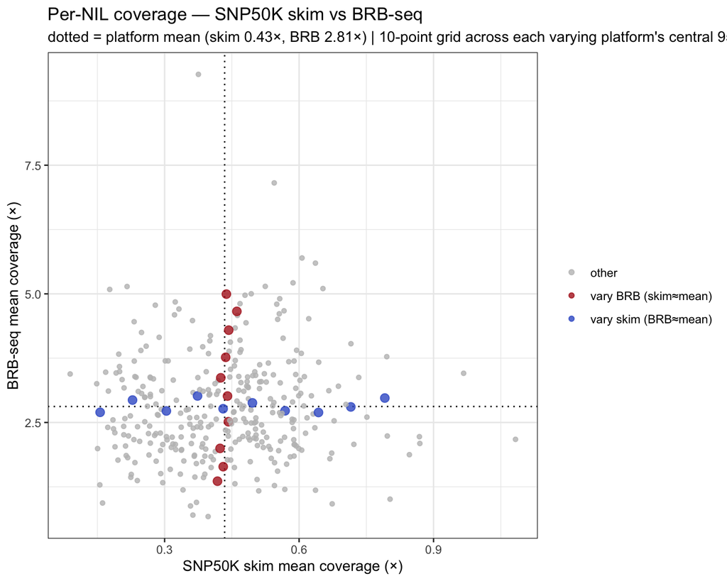

```r
cov2 <- cov %>% mutate(series = case_when(
  nil %in% vary_brb$nil & nil %in% vary_skim$nil ~ "both series",
  nil %in% vary_brb$nil  ~ "vary BRB (skim≈mean)",
  nil %in% vary_skim$nil ~ "vary skim (BRB≈mean)",
  TRUE ~ "other"))
ggplot(cov2, aes(skim_cov, brb_cov)) +
  geom_vline(xintercept = ms, linetype = "dotted") +
  geom_hline(yintercept = mb, linetype = "dotted") +
  geom_point(aes(colour = series, size = series == "other"), alpha = 0.8) +
  scale_size_manual(values = c(`TRUE` = 1.3, `FALSE` = 2.7), guide = "none") +
  scale_colour_manual(values = c(other = "grey75", `vary BRB (skim≈mean)` = "firebrick",
                                 `vary skim (BRB≈mean)` = "royalblue3", `both series` = "purple3"),
                      name = NULL) +
  labs(x = "SNP50K skim mean coverage (×)", y = "BRB-seq mean coverage (×)",
       title = "Per-NIL coverage — SNP50K skim vs BRB-seq",
       subtitle = sprintf("dotted = platform mean (skim %.2f×, BRB %.2f×) | 10-point grid across each varying platform's central 95%%",
                          ms, mb)) +
  theme_bw()
```

### The two coverage-matched series

**Vary BRB-seq** across its central 95%, **skim held ≈ mean** — sorted by BRB-seq λ:

```r
vary_brb %>% arrange(brb_cov) %>%
  transmute(NIL = nil, brb_cov = round(brb_cov,3), skim_cov = round(skim_cov,3),
            grid_target = round(grid_target,2), brb_sample = brb_name, skim_sample = skim_name) %>%
  knitr::kable(caption = "Skim held ≈ mean; BRB-seq λ stepped across its central 95% (P2.5–P97.5).")
```

Skim held ≈ mean; BRB-seq λ stepped across its central 95% (P2.5–P97.5).

| NIL | brb_cov | skim_cov | grid_target | brb_sample | skim_sample |
| --- | --- | --- | --- | --- | --- |
| Zh.0020_P3_P3_P1.4.1.1 | 1.359 | 0.418 | 1.19 | PN4_SID360 | PN9_SID821 |
| Zx.0570_P2_P2_P1.1.1.1 | 1.641 | 0.431 | 1.62 | PN4_SID336 | PN8_SID744 |
| Zd.0010_P2_P4_P2.3.1.1 | 1.997 | 0.424 | 2.05 | PN4_SID381 | PN14_SID1299 |
| Zx.0500_P2_P3_P2.1.1.1 | 2.515 | 0.442 | 2.48 | PN1_SID44 | PN4_SID348 |
| Zx.0570_P2_P1_P1.3.1.1 | 3.014 | 0.440 | 2.91 | PN3_SID236 | PN8_SID735 |
| Zh.0030_P4_P1_P2.3.1.1 | 3.368 | 0.425 | 3.34 | PN2_SID158 | PN9_SID836 |
| Zx.0550_P4_P4_P4.1.1.1 | 3.767 | 0.436 | 3.77 | PN2_SID110 | PN5_SID449 |
| Zl.0040_P4_P5_P2.4.1.1 | 4.294 | 0.443 | 4.20 | PN2_SID117 | PN11_SID982 |
| Zv.0070_P4_P5_P2.1.1.1 | 4.660 | 0.461 | 4.63 | PN1_SID71 | PN12_SID1064 |
| Zl.0040_P4_P1_P2.2.1.1 | 4.995 | 0.438 | 5.06 | PN1_SID47 | PN10_SID956 |

**Vary skim** across its central 95%, **BRB-seq held ≈ mean** — sorted by skim λ:

```r
vary_skim %>% arrange(skim_cov) %>%
  transmute(NIL = nil, skim_cov = round(skim_cov,3), brb_cov = round(brb_cov,3),
            grid_target = round(grid_target,3), skim_sample = skim_name, brb_sample = brb_name) %>%
  knitr::kable(caption = "BRB-seq held ≈ mean; skim λ stepped across its central 95% (P2.5–P97.5).")
```

BRB-seq held ≈ mean; skim λ stepped across its central 95% (P2.5–P97.5).

| NIL | skim_cov | brb_cov | grid_target | skim_sample | brb_sample |
| --- | --- | --- | --- | --- | --- |
| Zl.0040_P4_P3_P1.5.1.1 | 0.156 | 2.698 | 0.176 | PN11_SID962 | PN2_SID157 |
| Zd.0020_P3_P3_P1.2.1.1 | 0.228 | 2.936 | 0.242 | PN13_SID1243 | PN1_SID69 |
| Zv.0080_P2_P3_P1.1.1.1 | 0.304 | 2.724 | 0.309 | PN12_SID1101 | PN3_SID265 |
| Zx.0540_P3_P3_P1.1.1.1 | 0.373 | 3.016 | 0.376 | PN5_SID475 | PN2_SID164 |
| Zx.0100_P4_P3_P1.2.1.1 | 0.430 | 2.767 | 0.443 | PN3_SID225 | PN3_SID235 |
| Zx.0380_P2_P2_P2.3.1.1 | 0.496 | 2.881 | 0.510 | PN17_SID1576 | PN2_SID161 |
| Zl.0010_P1_P2_P2.3.1.1 | 0.569 | 2.728 | 0.577 | PN10_SID904 | PN2_SID181 |
| Zd.0030_P2_P5_P2.1.1.1 | 0.643 | 2.694 | 0.644 | PN7_SID579 | PN4_SID383 |
| Zl.0020_P3_P1_P2.4.1.1 | 0.715 | 2.803 | 0.711 | PN10_SID921 | PN2_SID145 |
| Zl.0020_P3_P4_P1.1.1.1 | 0.791 | 2.975 | 0.778 | PN10_SID939 | PN2_SID179 |

**Read:** BRB-seq (3′ RNA-seq) mean depth (~2.8×) sits well above the ~0.4× SNP50K skim, and the two platforms’ coverages are uncorrelated across NILs (library-driven). Each series steps one platform evenly across its central-95% coverage while holding the other ≈ its mean — a coverage-controlled sweep for asking how the ancestry calls move with the varying platform’s depth, with the other platform’s coverage held out as a confounder.

## Coverage-sweep chromosome painting

> **Clean-control note.** The BrB-seq B73 control is **`PN3_SID213`** (≈ 0 donor genome-wide). The plate-labeled `PN1_SID15` used previously is an **introgressed impostor** — 6 of the 35 BrB-seq “B73” reps carry real localized donor (all on plate PN1), a BRB-seq labeling artifact; skim/MolB B73 are clean. Per-experiment recommended clean controls: **B73 check QC**.

**BrB-RTI = wideseq-filtered, per-species, r=7.** BRB-seq 3′ markers are dense and noisy, so on the full joint-called SNP set RTIGER needed an extreme rigidity (r=109). Restricting the BRB allele counts to the **wideseq teosinte-informative positions** (21,665 of 66,983 SNPs; `data/brbseq_wideseq/brb_wideseq.vcf.gz`, GATK SelectVariants on the Chen2022 panel) strips the off-target noise and drops the **KS-calibrated rigidity to r=7** — chosen by minimizing `D = sup_x|F_called − F_sim|` of the donor-block size distribution vs the n=1500 BC2S3 simulation (`D=0.103`, vs 0.112 at the old r=109; median donor block 11.3 Mb ≈ the sim’s 10.74). Curve in `results/sim_calibration/brbseq_ks_wideseq/brbseq_ks_refined.csv`. BrB-RTI is fit **per teosinte species** (*Z. mays* ssp. *parviglumis* `Zv`, ssp. *mexicana* `Zx`, ssp. *huehuetenangensis* `Zh`, *Z. diploperennis* `Zd`, *Z. luxurians* `Zl`), B73 and Purple as separate checks (`brbseq_taxa_r7_wideseq`). The B73 check-group floor stays low (median ~0, mean ~0.05); the control `PN3_SID213` reads ≈ 0 donor.

```r
brb_sw  <- read_csv(params$brb_sweep,  show_col_types = FALSE)
skim_sw <- read_csv(params$skim_sweep, show_col_types = FALSE)
mem     <- read_csv(params$members,    show_col_types = FALSE)
BRB_B73 <- "PN3_SID213"; SKIM_B73 <- "PN10_SID893"   # clean B73 reps (PN1_SID15 is an introgressed impostor; see docs/b73_checks_qc.html)

lane2 <- function(seg, nm, method, rowlab) {
  d <- seg %>% filter(name == nm)
  if (!nrow(d)) return(NULL)
  tibble(row = rowlab, chr = d$chr, start_bp = d$start_bp, end_bp = d$end_bp,
         state = factor(d$state, 0:2, c("REF","HET","ALT")), method = method)
}
sweep_paint <- function(which) {
  m <- mem %>% filter(sweep == which) %>% arrange(vary_cov) %>%
    mutate(rowlab = sprintf("%.2f×<br>%s", vary_cov, gsub("_", "<br>", nil)))
  nil_rows <- pmap_dfr(list(m$skim_name, m$brb_name, m$rowlab), function(sk, br, rl)
    bind_rows(lane2(skim_sw, sk, "Skim-RTI", rl), lane2(brb_sw, br, "BrB-RTI", rl),
              lane2(skimbin, sk, "Skim-BIN", rl),           # Skim-BIN keyed on the skim sample name
              lane2(nilhmm,  sk, "Skim-nilHMM", rl),        # Skim-nilHMM keyed on the skim sample name
              lane2(brbnil,  br, "BrB-nilHMM", rl)))        # BrB-nilHMM keyed on the BRB sample name (like BrB-RTI)
  b73 <- bind_rows(lane2(skim_sw, SKIM_B73, "Skim-RTI", "**B73 control**"),
                   lane2(brb_sw,  BRB_B73,  "BrB-RTI",  "**B73 control**"),
                   lane2(skimbin, SKIM_B73, "Skim-BIN", "**B73 control**"),
                   lane2(nilhmm_chk, SKIM_B73, "Skim-nilHMM", "**B73 control**"),   # Skim-nilHMM B73 from its check group
                   lane2(brbnil_chk, BRB_B73, "BrB-nilHMM", "**B73 control**"))     # BrB-nilHMM B73 from its check group
  # B73 control pinned at the TOP; coverage rows keep their current descending order below
  bind_rows(b73, nil_rows) %>%
    mutate(chr = factor(chr, levels = 1:10, labels = paste0("chr", 1:10)),
           row = factor(row, levels = c("**B73 control**", rev(m$rowlab))),
           method = factor(method, c("Skim-BIN","Skim-RTI","Skim-nilHMM","BrB-RTI","BrB-nilHMM")),
           ylo = case_when(method == "Skim-BIN" ~ 0.80, method == "Skim-RTI" ~ 0.60,
                           method == "Skim-nilHMM" ~ 0.40, method == "BrB-RTI" ~ 0.20, TRUE ~ 0.00),
           yhi = case_when(method == "Skim-BIN" ~ 1.00, method == "Skim-RTI" ~ 0.79,
                           method == "Skim-nilHMM" ~ 0.59, method == "BrB-RTI" ~ 0.39, TRUE ~ 0.19))
}
paint_plot <- function(df, title, sub) {
  ggplot(df, aes(xmin = start_bp/1e6, xmax = end_bp/1e6, ymin = ylo, ymax = yhi, fill = state)) +
    geom_rect() +
    facet_grid(row ~ chr, scales = "free_x", space = "free_x", switch = "y") +
    scale_fill_manual(values = pal, drop = FALSE) +
    scale_x_continuous(labels = scales::unit_format(unit = "", scale = 1)) +
    scale_y_continuous(breaks = c(0.10, 0.30, 0.50, 0.70, 0.90),
                       labels = c("BrB-nilHMM","BrB-RTI","Skim-nilHMM","Skim-RTI","Skim-BIN"),
                       expand = expansion(mult = 0.02), position = "right") +
    labs(title = title, subtitle = sub, x = "Position (Mb)", fill = "Genotype") +
    ggpubr::theme_classic2(base_size = 9) +
    theme(legend.position = "bottom", strip.background = element_blank(),
          strip.text.x = element_text(face = "bold"),
          strip.text.y.left = ggtext::element_markdown(angle = 0, hjust = 1, size = 9, lineheight = 0.8),
          panel.spacing.x = unit(0.05, "lines"), panel.spacing.y = unit(0.18, "lines"),
          axis.text.y.right = element_text(size = 9), axis.ticks.y = element_blank(),
          axis.title.y = element_blank(), axis.line.y = element_blank(),
          axis.text.x = element_text(size = 6))
}
```

### Vary BRB-seq coverage (skim ≈ mean)

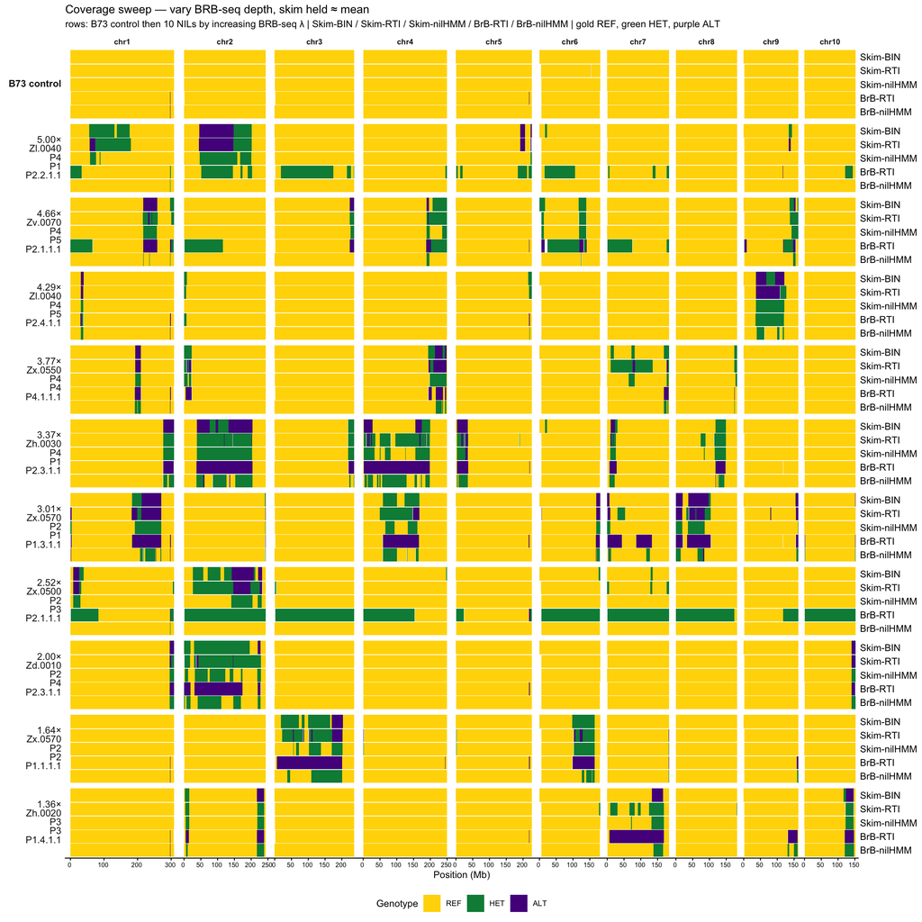

```r
paint_plot(sweep_paint("vary_brb"),
           "Coverage sweep — vary BRB-seq depth, skim held ≈ mean",
           "rows: B73 control then 10 NILs by increasing BRB-seq λ | Skim-BIN / Skim-RTI / Skim-nilHMM / BrB-RTI / BrB-nilHMM | gold REF, green HET, purple ALT")
```

### Vary skim coverage (BRB-seq ≈ mean)

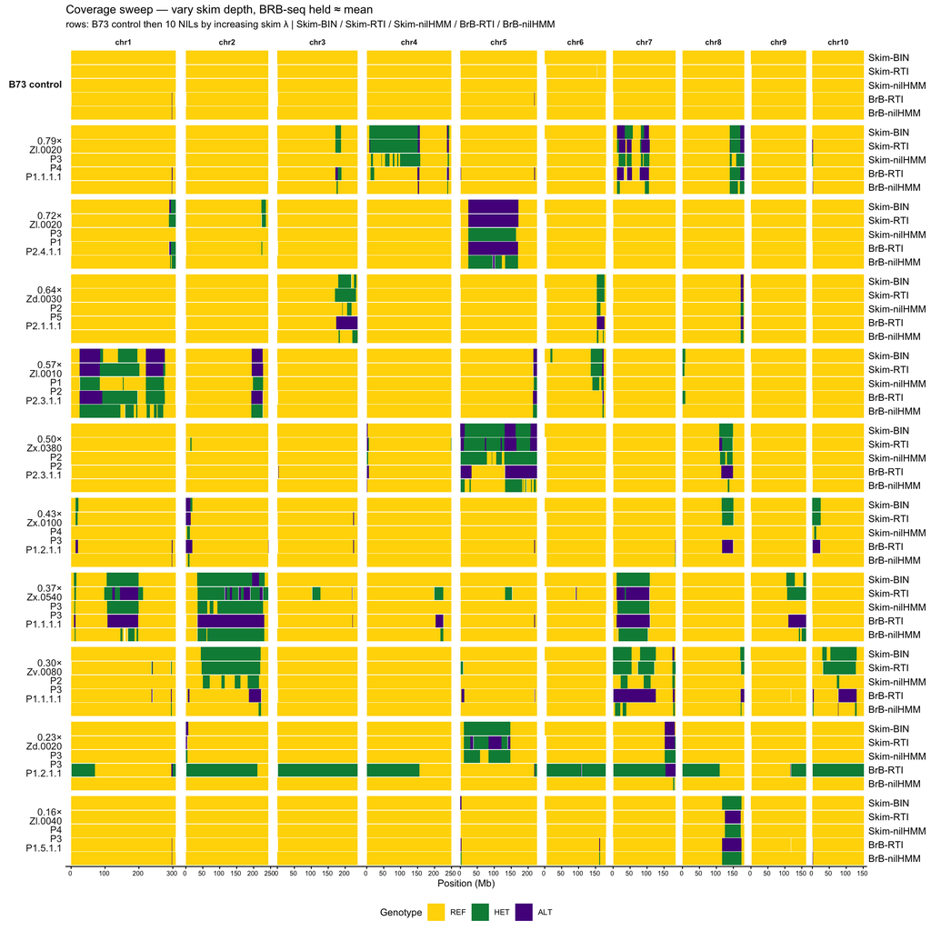

```r
paint_plot(sweep_paint("vary_skim"),
           "Coverage sweep — vary skim depth, BRB-seq held ≈ mean",
           "rows: B73 control then 10 NILs by increasing skim λ | Skim-BIN / Skim-RTI / Skim-nilHMM / BrB-RTI / BrB-nilHMM")
```

## Pedigree-matched pairs

```r
# pairwise donor Jaccard between two grid-projected state vectors (donor = state>0)
jac <- function(x, y) { ok <- !is.na(x) & !is.na(y); xd <- x[ok] > 0; yd <- y[ok] > 0
  u <- sum(xd | yd); if (u == 0) NA_real_ else sum(xd & yd) / u }
jac_one <- function(s_nil) {
  p <- matched[matched$nil == s_nil, ]
  k  <- state_on_grid(skim,    p$skim_name)   # Skim-RTI
  b  <- state_on_grid(brb,     p$brb_name)    # BrB-RTI
  n  <- state_on_grid(skimbin, p$skim_name)   # Skim-BIN     (same skim sample)
  h  <- state_on_grid(nilhmm,  p$skim_name)   # Skim-nilHMM  (same skim sample)
  hb <- state_on_grid(brbnil,  p$brb_name)    # BrB-nilHMM   (same BRB sample as BrB-RTI)
  tibble(J_RTI_BrB = jac(k, b), J_RTI_BIN = jac(k, n), J_RTI_nil = jac(k, h),
         J_BrB_BIN = jac(b, n), J_BrB_BrBnil = jac(b, hb),
         skim_donor = mean(k > 0, na.rm = TRUE), brb_donor = mean(b > 0, na.rm = TRUE),
         bin_donor = mean(n > 0, na.rm = TRUE), nil_donor = mean(h > 0, na.rm = TRUE),
         brbnil_donor = mean(hb > 0, na.rm = TRUE))
}
pair_tab <- matched %>% mutate(m = map(nil, jac_one)) %>% unnest(m) %>%
  transmute(NIL = nil, brb_label = brb_name, skim_sample = skim_name,
            J_RTI_BrB = round(J_RTI_BrB, 2), J_RTI_BIN = round(J_RTI_BIN, 2),
            J_RTI_nil = round(J_RTI_nil, 2), J_BrB_BIN = round(J_BrB_BIN, 2),
            J_BrB_BrBnil = round(J_BrB_BrBnil, 2),
            skim_donor = round(skim_donor, 3), brb_donor = round(brb_donor, 3),
            bin_donor = round(bin_donor, 3), nil_donor = round(nil_donor, 3),
            brbnil_donor = round(brbnil_donor, 3)) %>%
  arrange(desc(J_RTI_BrB))
knitr::kable(pair_tab,
             caption = "Per pedigree-matched NIL: pairwise donor Jaccard across the five callers (RTI=Skim-RTI, BrB=BrB-RTI, BIN=Skim-BIN, nil=Skim-nilHMM, BrBnil=BrB-nilHMM; J_RTI_nil = same-skim-reads and J_BrB_BrBnil = same-BRB-reads two-implementations checks) and per-caller donor fraction. (PN#_SID# plate labels for provenance only.)")
```

Per pedigree-matched NIL: pairwise donor Jaccard across the five callers (RTI=Skim-RTI, BrB=BrB-RTI, BIN=Skim-BIN, nil=Skim-nilHMM, BrBnil=BrB-nilHMM; J_RTI_nil = same-skim-reads and J_BrB_BrBnil = same-BRB-reads two-implementations checks) and per-caller donor fraction. (PN#_SID# plate labels for provenance only.)

| NIL | brb_label | skim_sample | J_RTI_BrB | J_RTI_BIN | J_RTI_nil | J_BrB_BIN | J_BrB_BrBnil | skim_donor | brb_donor | bin_donor | nil_donor | brbnil_donor |
| --- | --- | --- | --- | --- | --- | --- | --- | --- | --- | --- | --- | --- |
| Zx.0340_P2_P1_P1.1.1.1 | PN2_SID137 | PN4_SID290 | 0.79 | 0.79 | 0.70 | 0.78 | 0.29 | 0.083 | 0.090 | 0.072 | 0.059 | 0.025 |
| Zd.0030_P2_P1_P1.2.1.1 | PN2_SID169 | PN6_SID524 | 0.78 | 0.98 | 0.82 | 0.78 | 0.68 | 0.060 | 0.048 | 0.060 | 0.050 | 0.032 |
| Zv.0080_P2_P3_P1.1.1.1 | PN3_SID265 | PN12_SID1101 | 0.62 | 0.85 | 0.34 | 0.60 | 0.29 | 0.207 | 0.165 | 0.192 | 0.071 | 0.047 |
| Zx.0540_P3_P4_P4.3.1.1 | PN1_SID10 | PN6_SID492 | 0.31 | 0.69 | 0.60 | 0.25 | 0.00 | 0.166 | 0.432 | 0.134 | 0.101 | 0.001 |

## Confusion matrices — pairwise across callers (pooled, matched NILs)

```r
# grid-project all three callers per NIL (Skim-BIN keyed on the skim sample)
paired <- map_dfr(matched$nil, function(s_nil) {
  p <- matched[matched$nil == s_nil, ]
  tibble(nil  = s_nil,
         skim = state_on_grid(skim,    p$skim_name),
         brb  = state_on_grid(brb,     p$brb_name),
         bin  = state_on_grid(skimbin, p$skim_name),
         nilh = state_on_grid(nilhmm,  p$skim_name),
         brbnilh = state_on_grid(brbnil, p$brb_name))   # BrB-nilHMM (same BRB sample)
})
cats <- c("0 recurrent", "1 het", "2 donor")
cm_kable <- function(rows, cols, rlab, clab) {
  ok <- !is.na(rows) & !is.na(cols)
  cm <- table(factor(rows[ok], 0:2), factor(cols[ok], 0:2))
  prop <- sweep(cm, 1, rowSums(cm), "/")
  disp <- matrix(sprintf("%d (%.1f%%)", cm, 100*prop), nrow = 3, dimnames = list(cats, cats))
  knitr::kable(disp, align = "r",
               caption = sprintf("%s (rows) vs %s (cols): count (row %%). Overall concordance %.3f.",
                                 rlab, clab, sum(diag(cm)) / sum(cm)))
}
```

### Skim-RTI vs BrB-RTI

```r
cm_kable(paired$skim, paired$brb, "Skim-RTI", "BrB-RTI")
```

Skim-RTI (rows) vs BrB-RTI (cols): count (row %). Overall concordance 0.827.

|  | 0 recurrent | 1 het | 2 donor |
| --- | --- | --- | --- |
| 0 recurrent | 28759 (90.7%) | 2120 (6.7%) | 837 (2.6%) |
| 1 het | 957 (29.2%) | 407 (12.4%) | 1913 (58.4%) |
| 2 donor | 48 (3.4%) | 423 (29.9%) | 944 (66.7%) |

### Skim-RTI vs Skim-BIN — same reads, caller-only difference

```r
cm_kable(paired$skim, paired$bin, "Skim-RTI", "Skim-BIN")
```

Skim-RTI (rows) vs Skim-BIN (cols): count (row %). Overall concordance 0.945.

|  | 0 recurrent | 1 het | 2 donor |
| --- | --- | --- | --- |
| 0 recurrent | 31595 (99.4%) | 191 (0.6%) | 13 (0.0%) |
| 1 het | 695 (21.1%) | 2460 (74.7%) | 137 (4.2%) |
| 2 donor | 64 (4.5%) | 917 (64.5%) | 441 (31.0%) |

### Skim-RTI vs Skim-nilHMM — same reads, two count-HMM implementations

```r
cm_kable(paired$skim, paired$nilh, "Skim-RTI", "Skim-nilHMM")
```

Skim-RTI (rows) vs Skim-nilHMM (cols): count (row %). Overall concordance 0.905.

|  | 0 recurrent | 1 het | 2 donor |
| --- | --- | --- | --- |
| 0 recurrent | 31799 (100.0%) | 0 (0.0%) | 0 (0.0%) |
| 1 het | 2055 (62.4%) | 1236 (37.6%) | 0 (0.0%) |
| 2 donor | 104 (7.3%) | 1315 (92.7%) | 0 (0.0%) |

### BrB-RTI vs BrB-nilHMM — same BRB reads, two implementations

```r
cm_kable(paired$brb, paired$brbnilh, "BrB-RTI", "BrB-nilHMM")
```

BrB-RTI (rows) vs BrB-nilHMM (cols): count (row %). Overall concordance 0.818.

|  | 0 recurrent | 1 het | 2 donor |
| --- | --- | --- | --- |
| 0 recurrent | 29802 (100.0%) | 0 (0.0%) | 0 (0.0%) |
| 1 het | 2959 (100.0%) | 0 (0.0%) | 0 (0.0%) |
| 2 donor | 2749 (74.2%) | 937 (25.3%) | 21 (0.6%) |

### BrB-RTI vs Skim-BIN

```r
cm_kable(paired$brb, paired$bin, "BrB-RTI", "Skim-BIN")
```

BrB-RTI (rows) vs Skim-BIN (cols): count (row %). Overall concordance 0.831.

|  | 0 recurrent | 1 het | 2 donor |
| --- | --- | --- | --- |
| 0 recurrent | 28957 (97.2%) | 830 (2.8%) | 15 (0.1%) |
| 1 het | 2145 (72.5%) | 806 (27.2%) | 8 (0.3%) |
| 2 donor | 1216 (32.6%) | 1949 (52.2%) | 568 (15.2%) |

## Introgression-size distribution

Donor-block sizes (runs of donor state — HET or ALT — collapsed per chromosome) pooled across the **full set of NILs called on *both* platforms** (pedigree-matched via the correspondence; BrB-RTI from the per-species fit). All five callers: **Skim-RTI**, **Skim-BIN**, and **Skim-nilHMM** on the same skim reads, **BrB-RTI** and **BrB-nilHMM** on the same BRB reads. Grey curve is the **Null** n=1500 BC2S3 simulation — the modeled expectation under no selection.

```r
brb_taxa <- read_csv(params$brb_taxa, show_col_types = FALSE)   # full per-species BrB-RTI (379)
nil_seg  <- read_csv(params$nil_seg,  show_col_types = FALSE)   # n=1500 sim (NULL)

# FULL set of NILs with calls on BOTH platforms (pedigree-matched, ";"-split replicates)
brb_in  <- corr %>% separate_rows(brbseq_prefix, sep = ";") %>%
  transmute(name = brbseq_prefix, nil = pedigree) %>% filter(name %in% brb_taxa$name)
skim_in <- corr %>% separate_rows(skim_prefix,  sep = ";") %>%
  transmute(name = skim_prefix,  nil = pedigree) %>% filter(name %in% skim$name)
both_nils <- intersect(brb_in$nil, skim_in$nil)

# introgression block = maximal run of donor (state>0) within a (sample, chromosome)
donor_blocks <- function(seg) seg %>% arrange(name, chr, start_bp) %>% group_by(name, chr) %>%
  mutate(run = cumsum(c(TRUE, diff(state > 0) != 0)), donor = state > 0) %>% filter(donor) %>%
  group_by(name, chr, run) %>% summarise(size_mb = (max(end_bp) - min(start_bp))/1e6, .groups = "drop")

skim_b <- donor_blocks(skim     %>% filter(name %in% skim_in$name[skim_in$nil %in% both_nils])) %>%
  mutate(src = "Skim-RTI (r=5)")
brb_b  <- donor_blocks(brb_taxa %>% filter(name %in% brb_in$name[brb_in$nil  %in% both_nils])) %>%
  mutate(src = "BrB-RTI (r=7, ws)")
# Skim-BIN on the SAME skim samples as Skim-RTI (keyed on skim name)
bin_b  <- donor_blocks(skimbin  %>% filter(name %in% skim_in$name[skim_in$nil %in% both_nils])) %>%
  mutate(src = "Skim-BIN (1 Mb)")
# Skim-nilHMM on the SAME skim samples (keyed on skim name)
nil_b  <- donor_blocks(nilhmm   %>% filter(name %in% skim_in$name[skim_in$nil %in% both_nils])) %>%
  mutate(src = "Skim-nilHMM (counts)")
# BrB-nilHMM on the SAME BRB samples as BrB-RTI (keyed on BRB name)
brbnil_b <- donor_blocks(brbnil %>% filter(name %in% brb_in$name[brb_in$nil %in% both_nils])) %>%
  mutate(src = "BrB-nilHMM (counts)")
null_b <- nil_seg %>% transmute(size_mb = mb)
cat(sprintf("NILs on both platforms: %d | Skim-RTI %d | BrB-RTI %d | Skim-BIN %d | Skim-nilHMM %d | BrB-nilHMM %d blocks\n",
            length(both_nils), nrow(skim_b), nrow(brb_b), nrow(bin_b), nrow(nil_b), nrow(brbnil_b)))
```

```
NILs on both platforms: 332 | Skim-RTI 1915 | BrB-RTI 2846 | Skim-BIN 1783 | Skim-nilHMM 1831 | BrB-nilHMM 2595 blocks
```

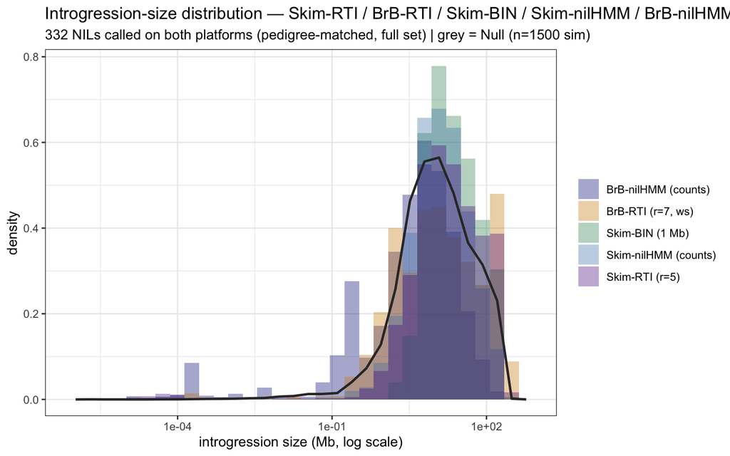

```r
ggplot(bind_rows(skim_b, brb_b, bin_b, nil_b, brbnil_b), aes(x = size_mb, fill = src)) +
  geom_histogram(aes(y = after_stat(density)), position = "identity", alpha = 0.35, bins = 30) +
  geom_freqpoly(data = null_b, aes(x = size_mb, y = after_stat(density)),
                bins = 30, colour = "grey20", linewidth = 0.9, inherit.aes = FALSE) +
  scale_fill_manual(values = c("Skim-RTI (r=5)" = "purple4", "BrB-RTI (r=7, ws)" = "orange3",
                               "Skim-BIN (1 Mb)" = "seagreen4", "Skim-nilHMM (counts)" = "steelblue",
                               "BrB-nilHMM (counts)" = "navy")) +
  scale_x_log10() +
  labs(x = "introgression size (Mb, log scale)", y = "density", fill = NULL,
       title = "Introgression-size distribution — Skim-RTI / BrB-RTI / Skim-BIN / Skim-nilHMM / BrB-nilHMM",
       subtitle = sprintf("%d NILs called on both platforms (pedigree-matched, full set) | grey = Null (n=1500 sim)",
                          length(both_nils))) +
  theme_bw()
```

## Genotype-frequency distribution vs the one-locus expectation

Per-NIL genome fraction called **HET** and **homozygous ALT (donor)** by each caller, across the full both-platforms set, versus two references: the **n=1500 Broman/simcross BC2S3 simulation** (grey — the expected *distribution* of per-NIL fractions) and its **single-locus mean** `p0` (dashed; `R/07_single_locus.R`, the breeding-scheme transition-matrix expectation, map- and interference-independent). For BC2S3 the donor allele frequency is fixed at 0.125 but selfing has driven most of it to **homozygous** donor, so the expectation is **ALT ≫ HET**. A caller that over-calls HET (RNA allelic noise) or under-resolves donor blocks will deviate from both the simulated spread and `p0`.

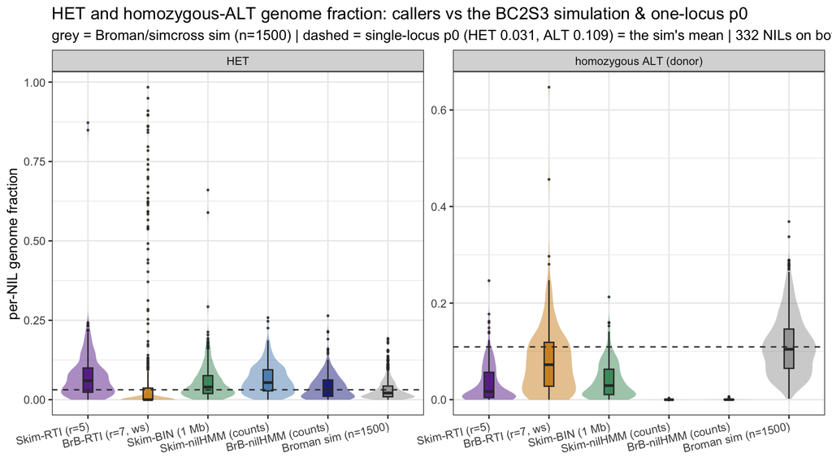

```r
source("R/07_single_locus.R")
p0 <- single_locus_p0(n_bc = 2L, n_self = 3L)   # BC2S3 one-locus expectation c(REF, Het, ALT)

# per-sample HET & ALT genome fraction (length-weighted) for a call set
state_freq <- function(seg, nms, method) {
  seg %>% filter(name %in% nms) %>% mutate(l = end_bp - start_bp + 1) %>% group_by(name) %>%
    summarise(Het = sum(l[state == 1]) / sum(l), ALT = sum(l[state == 2]) / sum(l),
              .groups = "drop") %>% mutate(method = method)
}
sk_names  <- unique(skim_in$name[skim_in$nil %in% both_nils])   # skim samples (Skim-RTI & Skim-BIN)
brb_names <- unique(brb_in$name[brb_in$nil  %in% both_nils])    # BrB samples
freq <- bind_rows(
  state_freq(skim,    sk_names,  "Skim-RTI (r=5)"),
  state_freq(brb,     brb_names, "BrB-RTI (r=7, ws)"),
  state_freq(skimbin, sk_names,  "Skim-BIN (1 Mb)"),
  state_freq(nilhmm,  sk_names,  "Skim-nilHMM (counts)"),
  state_freq(brbnil,  brb_names, "BrB-nilHMM (counts)"),          # nilHMM on the BRB reads (keyed on BRB names)
  read_csv(params$broman_frac, show_col_types = FALSE) %>%       # n=1500 simcross BC2S3 simulation
    transmute(name = as.character(nil_id), Het, ALT, method = "Broman sim (n=1500)")) %>%
  pivot_longer(c(Het, ALT), names_to = "state", values_to = "freq") %>%
  mutate(method = factor(method, c("Skim-RTI (r=5)", "BrB-RTI (r=7, ws)", "Skim-BIN (1 Mb)", "Skim-nilHMM (counts)", "BrB-nilHMM (counts)", "Broman sim (n=1500)")),
         state  = factor(state, c("Het", "ALT"), c("HET", "homozygous ALT (donor)")))
expd <- tibble(state = factor(c("HET", "homozygous ALT (donor)"),
                              c("HET", "homozygous ALT (donor)")),
               expected = c(p0[["Het"]], p0[["ALT"]]))

ggplot(freq, aes(method, freq, fill = method)) +
  geom_violin(alpha = 0.45, scale = "width", colour = NA) +
  geom_boxplot(width = 0.16, outlier.size = 0.4, alpha = 0.8) +
  geom_hline(data = expd, aes(yintercept = expected), linetype = "dashed", colour = "grey20") +
  facet_wrap(~ state, scales = "free_y") +
  scale_fill_manual(values = c("Skim-RTI (r=5)" = "purple4", "BrB-RTI (r=7, ws)" = "orange3",
                               "Skim-BIN (1 Mb)" = "seagreen4", "Skim-nilHMM (counts)" = "steelblue",
                               "BrB-nilHMM (counts)" = "navy", "Broman sim (n=1500)" = "grey60"), guide = "none") +
  labs(x = NULL, y = "per-NIL genome fraction",
       title = "HET and homozygous-ALT genome fraction: callers vs the BC2S3 simulation & one-locus p0",
       subtitle = sprintf("grey = Broman/simcross sim (n=1500) | dashed = single-locus p0 (HET %.3f, ALT %.3f) = the sim's mean | %d NILs on both platforms",
                          p0[["Het"]], p0[["ALT"]], length(both_nils))) +
  theme_bw() + theme(axis.text.x = element_text(angle = 12, hjust = 1))
```

**Read:** the expectation is **HET ≈ 0.031**, **ALT ≈ 0.109** (donor allele fixed at 0.125, mostly homozygous after S3). A caller sitting above the dashed HET line / below the ALT line is over-calling heterozygosity — the RNA-noise failure mode BrB-RTI is most prone to. **BrB-nilHMM** (same BRB reads) suppresses that high-HET tail (per-sample HET p90 0.44 → 0.09), but at the cost of **under-calling donor and collapsing ALT → HET** (ALT ≈ 0) — read its donor footprint, not its HET/ALT split (⚠ note above; `agent/nilhmm/BRB_run_findings.md`).

## Chromosome painting — Skim-RTI / BrB-RTI / Skim-BIN / Skim-nilHMM / BrB-nilHMM per NIL

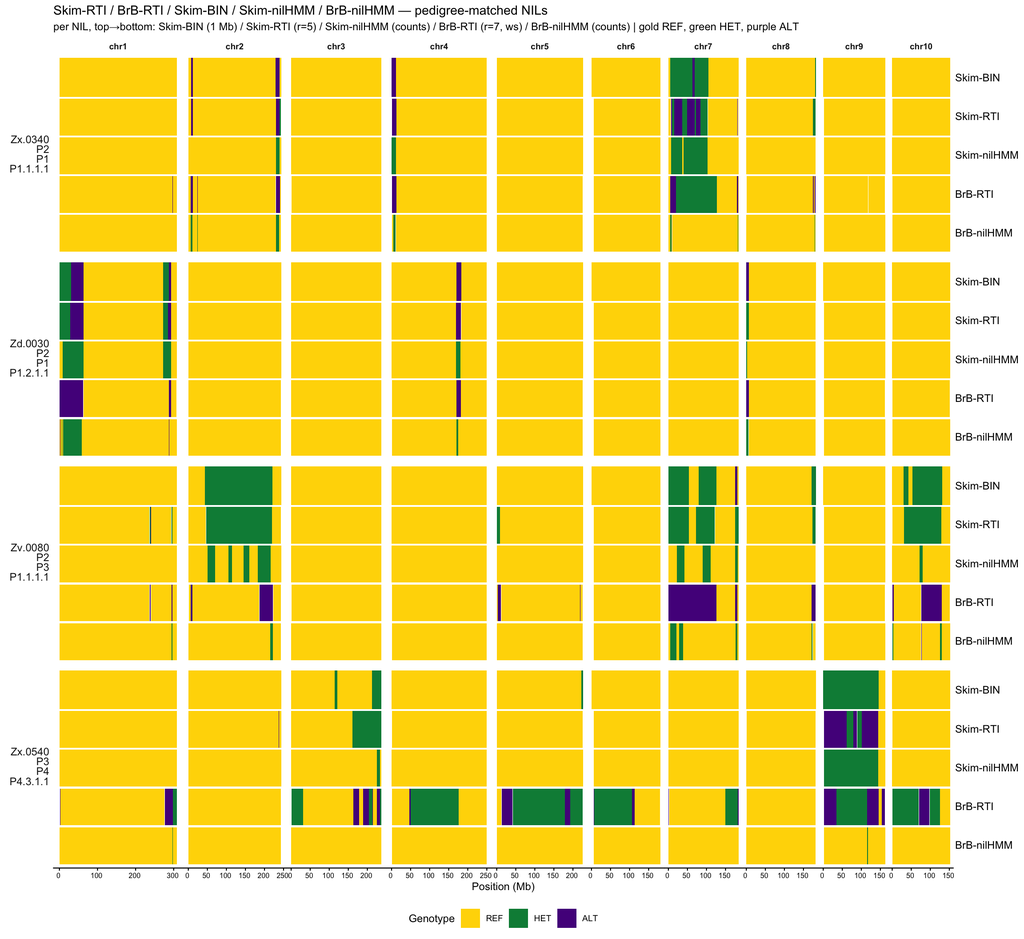

```r
nil_ord <- pair_tab$NIL
lane <- function(seg, nm, method, s_nil) {
  d <- seg[seg$name == nm, ]
  tibble(nil = s_nil, chr = d$chr, start_bp = d$start_bp, end_bp = d$end_bp,
         state = factor(d$state, 0:2, c("REF","HET","ALT")), method = method)
}
paint <- map_dfr(matched$nil, function(s_nil) {
  p <- matched[matched$nil == s_nil, ]
  bind_rows(lane(skim,    p$skim_name, "Skim-RTI",    s_nil),
            lane(brb,     p$brb_name,  "BrB-RTI",     s_nil),
            lane(skimbin, p$skim_name, "Skim-BIN",    s_nil),    # same skim sample
            lane(nilhmm,  p$skim_name, "Skim-nilHMM", s_nil),    # same skim sample
            lane(brbnil,  p$brb_name,  "BrB-nilHMM",  s_nil))    # same BRB sample as BrB-RTI
}) %>%
  mutate(chr  = factor(chr, levels = 1:10, labels = paste0("chr", 1:10)),
         nil  = factor(gsub("_", "<br>", nil), levels = gsub("_", "<br>", nil_ord)),
         method = factor(method, c("Skim-BIN","Skim-RTI","Skim-nilHMM","BrB-RTI","BrB-nilHMM")),
         ylo = case_when(method == "Skim-BIN" ~ 0.80, method == "Skim-RTI" ~ 0.60,
                         method == "Skim-nilHMM" ~ 0.40, method == "BrB-RTI" ~ 0.20, TRUE ~ 0.00),
         yhi = case_when(method == "Skim-BIN" ~ 1.00, method == "Skim-RTI" ~ 0.79,
                         method == "Skim-nilHMM" ~ 0.59, method == "BrB-RTI" ~ 0.39, TRUE ~ 0.19))

ggplot(paint, aes(xmin = start_bp/1e6, xmax = end_bp/1e6, ymin = ylo, ymax = yhi, fill = state)) +
  geom_rect() +
  facet_grid(nil ~ chr, scales = "free_x", space = "free_x", switch = "y") +
  scale_fill_manual(values = pal, drop = FALSE) +
  scale_x_continuous(labels = scales::unit_format(unit = "", scale = 1)) +
  scale_y_continuous(breaks = c(0.10, 0.30, 0.50, 0.70, 0.90),
                     labels = c("BrB-nilHMM","BrB-RTI","Skim-nilHMM","Skim-RTI","Skim-BIN"),
                     expand = expansion(mult = 0.02), position = "right") +
  labs(title = "Skim-RTI / BrB-RTI / Skim-BIN / Skim-nilHMM / BrB-nilHMM — pedigree-matched NILs",
       subtitle = "per NIL, top→bottom: Skim-BIN (1 Mb) / Skim-RTI (r=5) / Skim-nilHMM (counts) / BrB-RTI (r=7, ws) / BrB-nilHMM (counts) | gold REF, green HET, purple ALT",
       x = "Position (Mb)", fill = "Genotype") +
  ggpubr::theme_classic2(base_size = 9) +
  theme(legend.position = "bottom", strip.background = element_blank(),
        strip.text.x = element_text(face = "bold"),
        strip.text.y.left = ggtext::element_markdown(angle = 0, hjust = 1, size = 9, lineheight = 0.85),
        panel.spacing.x = unit(0.05, "lines"), panel.spacing.y = unit(0.15, "lines"),
        axis.text.y.right = element_text(size = 9), axis.ticks.y = element_blank(),
        axis.title.y = element_blank(), axis.line.y = element_blank(),
        axis.text.x = element_text(size = 6))
```